# PTEBAR - At-sea tracking

Data exploration - part 1

# 1 Mise en contexte

## 1.1 Mission 1 - Grand Bénare - 18 au 19 décembre 2018

Dans le cadre du projet Life + Pétrels, 10 balises GPS ont été déployées sur des pétrels de Barau entre le 18-12-2018 et le 19-12-2018. Les balises sont des GPS écotone type PICA de 5g. Les individus équipés sont tous nicheurs et localisés dans la vallée des Deux Miches (**Tab. 1**). Un des but du déployement de cette technologie était de décrire finement les zones de passage ainsi que l’altitude de vol des pétrels lors des entrées et des sorties de la colonie de reproduction.

La configuration des GPS est la suivante:  
- SOIR : activation de 16:30 à 22h30 (heure locale)  
- MATIN : activation de 2:30 à 6h30 (heure locale)  
- Fréquence d’acquisitaion : 1 point/min  
- Base range : en marche (indication sur la présence ou non de l’individu au terrier)  
- No GPS signal : le GPS s’éteint

Tab. 1. Bilan de la localisation des nids (nest_ID, nest_X & nest_Y) et du statut des individus équipés avec un GPS. ring_ID = numéro de bague, breed_stat = statut de reproduction avec AD/O, adulte sur oeuf, AD/P, adulte sur poussin & 2AD/echec, 2 adultes dans le nid avec echec de repro, ring_year = année de baguage de l individu, weight = poids en g.

| nest_ID | nest_X | nest_Y | Logger_ID | ring_ID | breed_stat | ring_year | weight | GPS_config |
| --- | --- | --- | --- | --- | --- | --- | --- | --- |
| 11 | 336472.5 | 7663571 | PAC10 | FS75797 | AD/O | 2009 | 430 | MATIN |
| 12 | 336472.5 | 7663571 | PAC12 | GE41695 | AD/O | 2014 | 430 | MATIN |
| 13 | 336472.5 | 7663571 | PAC06 | FS88846 | AD/O | 2014 | 400 | MATIN |
| 20 | 336484.4 | 7663586 | PAC04 | FS88926 | 2AD/echec | 2013 | 410 | SOIR |
| 30 | 336499.7 | 7663609 | PAC15 | FS88338 | AD/P | 2012 | 390 | SOIR |
| 31 | 336502.3 | 7663609 | PAC16 | GE41788 | AD/O | 2015 | 470 | SOIR |
| 100 | 336488.4 | 7663591 | PAC14 | FX24893 | AD/O | 2018 | 420 | MATIN |
| 103 | 336484.4 | 7663586 | PAC03 | FX24884 | AD/P | 2018 | 410 | MATIN |
| 104 | 336504.3 | 7663608 | PAC20 | FS88360 | AD/O | 2012 | 420 | SOIR |
| 108 | 336447.0 | 7663586 | PAC11 | FX25185 | AD/O | 2017 | 390 | SOIR |
| NA | NA | NA | PAC05 | NA | NA | NA | NA | NA |
| NA | NA | NA | PAC13 | NA | NA | NA | NA | NA |

## 1.2 Mission 2 - Grand Bénare - 9 au 10 janvier 2019

Au cours de cette mission, aucun GPS n’a été récupéré et aucune donnée n’a été réceptionnée par l’antenne. De plus, certains individus semblent avoir changé de partenaire (**Tab. 2**).

Tab. 2. Bilan du suivi des nids occupés par les adultes avec GPS à lors de la mission précédente. pul = poussin

| nest_ID | nest_X | nest_Y | Logger_ID | nest_status | ring_ind1 | ring_ind2 | rmq |
| --- | --- | --- | --- | --- | --- | --- | --- |
| 11 | 336472.5 | 7663571 | PAC10 | vide |  |  | vide le 11/2019 |
| 12 | 336472.5 | 7663571 | PAC12 | pul seul | FS78167 | FS88849 | ind2=nouveau partenaire? |
| 13 | 336472.5 | 7663571 | PAC06 | vide |  |  | vide le 11/2019 |
| 20 | 336484.4 | 7663586 | PAC04 | pul seul |  |  | TPROF 11/2019 |
| 30 | 336499.7 | 7663609 | PAC15 | vide |  |  | AD INAX puis TPROF le 11/2019 |
| 31 | 336502.3 | 7663609 | PAC16 | vide |  |  | AD INAX puis TPROF le 11/2019 |
| 100 | 336488.4 | 7663591 | PAC14 | non trouvé | FL38093 |  | AD/O le11/2019 |
| 103 | 336484.4 | 7663586 | PAC03 | vide | pas d ind | pas d ind | vide le 01/2019 |
| 104 | 336504.3 | 7663608 | PAC20 | vide | FX24885 | FX24691 | ind2=nouveau partenaire? |
| 108 | 336447.0 | 7663586 | PAC11 | AD non bagué |  |  | vide le 11/2019 |
| NA | NA | NA | PAC05 | NA | NA | NA | NA |
| NA | NA | NA | PAC13 | NA | NA | NA | NA |

## 1.3 Mission 3 - Grand Bénare - 11 au 12 février 2019

Aucun oiseau avec GPS n’a été contrôlé sur la colonie. La communication entre les GPS et l’antenne deployée sur colonie (GPS point ?) semble avoir été faible, avec peu de données transmises : 4 GPS sur 10 et disparition du GPS **PAC20** (**Tab. 3**). Suite à ces observations, l’emplacement du récepteur de signal a été modifié (point GPS ?) afin d’optimiser la communication entre le récepteur et les GPS. La configuration des GPS a également été modifiée:  
- SOIR : activation de 17:00 à 23:00 (heure locale)  
- MATIN : activation de 3:00 à 7:00 (heure locale)

Tab. 3. Nombre de points enregistrés par GPS en date du 11 et 12 novembre 2019

| nest_ID | Logger_ID | N_records | ring_ID | GPS_config |
| --- | --- | --- | --- | --- |
| 11 | PAC10 | 1 | FS75797 | MATIN |
| 13 | PAC06 | 1 | FS88846 | MATIN |
| 12 | PAC12 | 2 | GE41695 | MATIN |
| 100 | PAC14 | 4 | FX24893 | MATIN |
| 20 | PAC04 | 10 | FS88926 | SOIR |
| 30 | PAC15 | 173 | FS88338 | SOIR |
| 108 | PAC11 | 271 | FX25185 | SOIR |
| 103 | PAC03 | 403 | FX24884 | MATIN |
| 31 | PAC16 | 893 | GE41788 | SOIR |
| 104 | PAC20 | NA | FS88360 | SOIR |

## 1.4 Mission 4 - Grand Bénare - 4 septembre 2019

Cette mission a permis de redéployer l’antenne réceptrice de données GPS sur la colonie de pétrel de Barau. Aucune donnée n’a été reçu. Les terriers des individus équipés l’année précédente ont été visités. Sur 10 nids, seulement deux (nids 20 & 108) étaient occupés par le partenaire de l’oiseau équipé.

## 1.5 Limitations

- Il semblerait qu’aucun des oiseaux avec une balise GPS n’aient été recontrôlés depuis le déploiement. Cela remet en question la méthode du *back-pack* utilisé pour installer les balises.
- La configuration des GPS n’a peut-être pas été prise en compte puisque les données ne présentent pas d’altitude et que des points GPS ont été enregistrés au-delà des heures d’activation de la balise (MATIN vs SOIR, sauf si mécompréhension du protocole et que ce créneau horaire correspond au moment où les balises peuvent communiquer avec l’antenne réceptrice).
- Les balises **PAC05** & **PAC13** ne sont pas répertoriées dans les comptes rendus (CR) de missions *tracking*. Cependant, deux balises (**PAC20** & **PAC14**) sont mentionnées dans le CR mais n’apparaissent pas dans le jeux de données.

# 2 Bilan data brutes

Le **tableau 4** fait le bilan des données GPS déployés sur les 10 individus nichant au Grand Bénarre en décembre 2018.

| log_ID | point_numb | NA_numb | prop_NA (%) | time_min | time_max |
| --- | --- | --- | --- | --- | --- |
| PAC04 | 18 | 8 | 44.4 | 2018-12-18 09:26:00 | 2018-12-18 09:41:45 |
| PAC13 | 73 | 38 | 52.1 | 2019-01-22 07:38:00 | 2019-01-22 08:19:01 |
| PAC05 | 429 | 174 | 40.6 | 2019-01-22 07:38:00 | 2019-01-22 08:21:09 |
| PAC11 | 446 | 78 | 17.5 | 2018-12-18 09:27:00 | 2019-03-27 16:08:28 |
| PAC10 | 553 | 49 | 8.9 | 2018-12-18 09:40:04 | 2019-03-26 20:37:00 |
| PAC03 | 2309 | 141 | 6.1 | 2018-12-18 09:40:02 | 2019-03-20 23:00:46 |
| PAC06 | 2505 | 116 | 4.6 | 2018-12-18 09:40:28 | 2019-03-29 17:55:57 |
| PAC12 | 3579 | 201 | 5.6 | 2018-05-18 11:33:00 | 2019-03-28 22:42:50 |
| PAC15 | 3730 | 157 | 4.2 | 2018-12-18 09:26:00 | 2019-03-28 00:15:09 |
| PAC16 | 5012 | 84 | 1.7 | 2018-12-18 09:27:00 | 2019-04-05 16:45:36 |

# 3 Bilan des données non dupliquées

Les données ont été filtrées à partir de la variable **time** (composée de la date et de l’heure lors de l’enregistrement du point GPS). Dans le cas où deux dates identiques pour un même GPS sont présentes, la ligne conservée est celle qui présente le **searching_time** (time to fix) le plus court. Les lignes avec des *NA* pour lat/long ont été retirés. Les balises dysfonctionnelles ont également été exclues (*PAC04*, *PAC13* & *PAC05*). Les données restantes sont résumées dans le **tableau 5**.

| log_ID | point_numb | time_min | time_max | speed_min (km/h) | speed_max (km/h) |
| --- | --- | --- | --- | --- | --- |
| PAC04 | 8 | 2018-12-18 09:26:00 | 2018-12-18 09:34:00 | 0 | 0.926 |
| PAC13 | 34 | 2019-01-22 07:38:00 | 2019-01-22 08:18:00 | 0 | 1.852 |
| PAC05 | 42 | 2019-01-22 07:38:00 | 2019-01-22 08:20:00 | 0 | 2.9632 |
| PAC11 | 366 | 2018-12-18 09:27:00 | 2019-03-09 17:24:00 | 0 | 62.968 |
| PAC10 | 503 | 2018-12-18 09:41:00 | 2019-03-26 20:37:00 | 0 | 83.34 |
| PAC03 | 2168 | 2018-12-18 09:41:00 | 2019-03-05 00:45:00 | 0 | 96.304 |
| PAC06 | 2389 | 2018-12-18 09:41:00 | 2019-03-16 22:02:00 | 0 | 101.86 |
| PAC12 | 3378 | 2018-05-18 11:33:00 | 2019-03-26 23:00:00 | 0 | 81.488 |
| PAC15 | 3571 | 2018-12-18 09:26:00 | 2019-03-26 18:47:00 | 0 | 94.452 |
| PAC16 | 4926 | 2018-12-18 09:27:00 | 2019-03-26 20:12:00 | 0 | 90.748 |

# 4 Visualisation des trajets

[interactive chart not shown]

Carte 1. Représentation des trajets complets pour les sept balises GPS restantes.

# 5 Points sur terre

[interactive chart not shown]

Carte 2. Représentation des passages d’entrées et de sorties de la colonie du Grand Bénare, n = 7 balises.

# 6 Points en mer

[interactive chart not shown]

Carte 3. Représentation des trajets en mer et de la fréquence d’acquisition des points GPS pour les 7 balises GPS. # Fréquence d’enregistrement par GPS

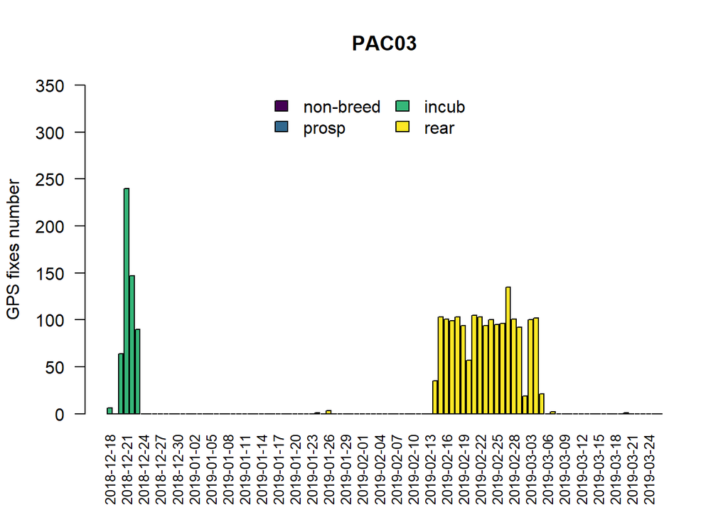

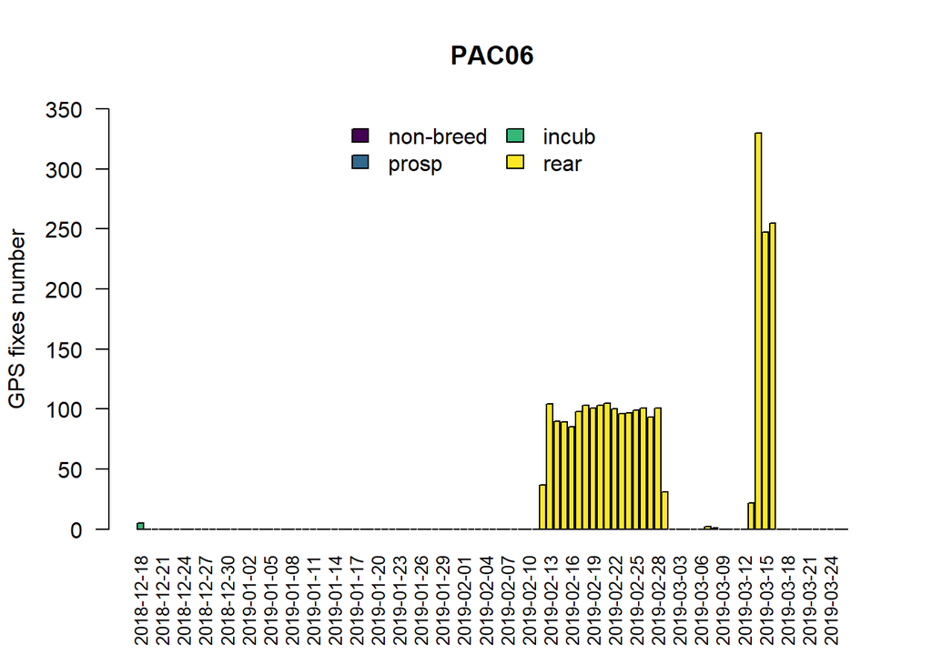

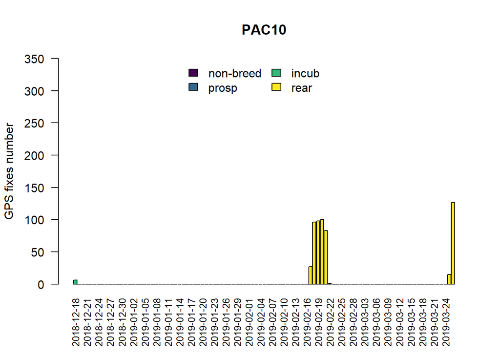

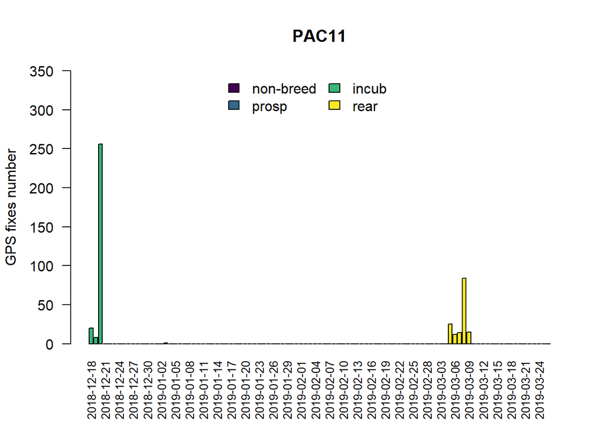

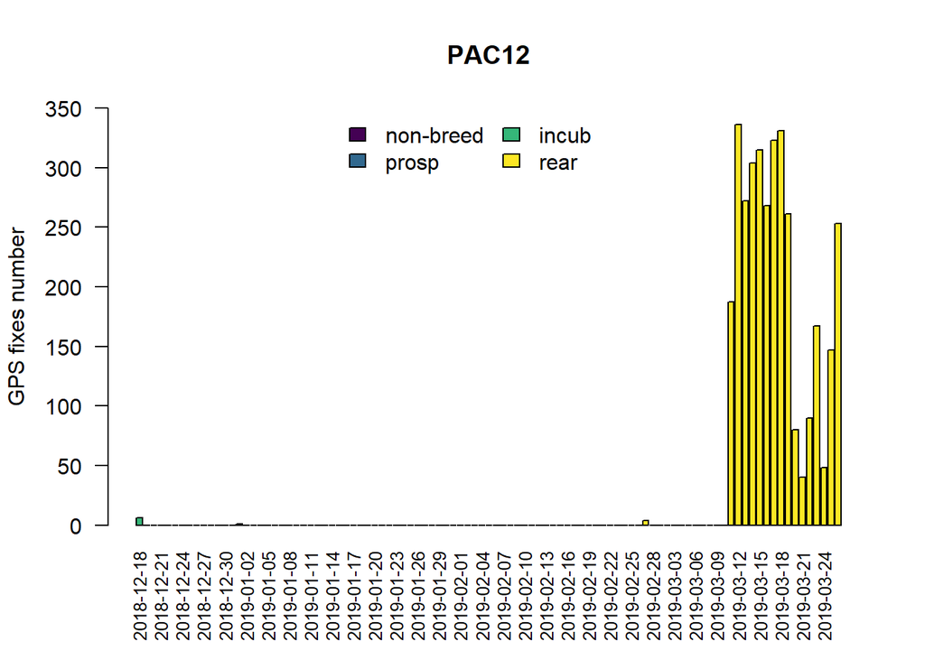

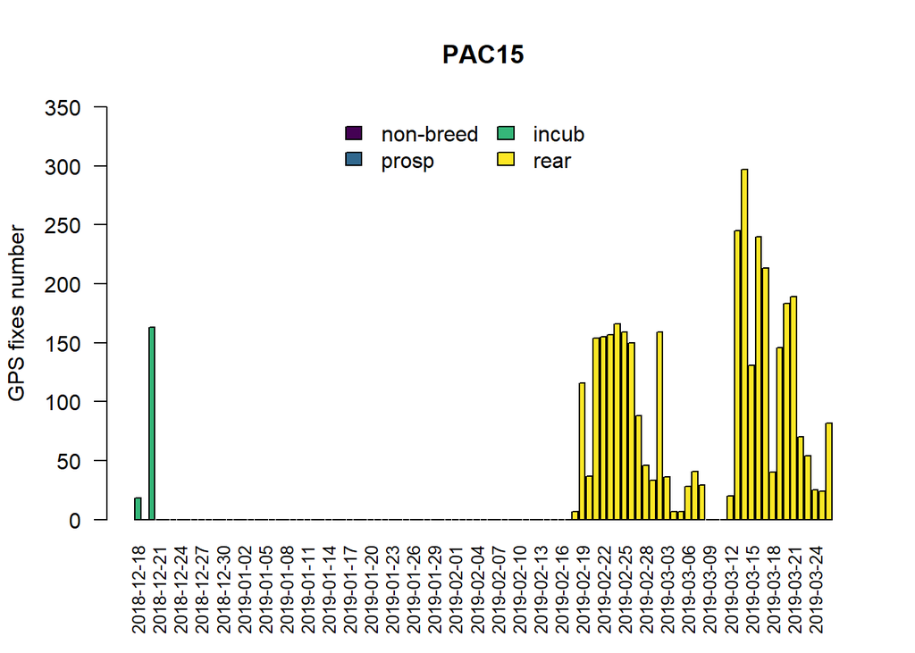

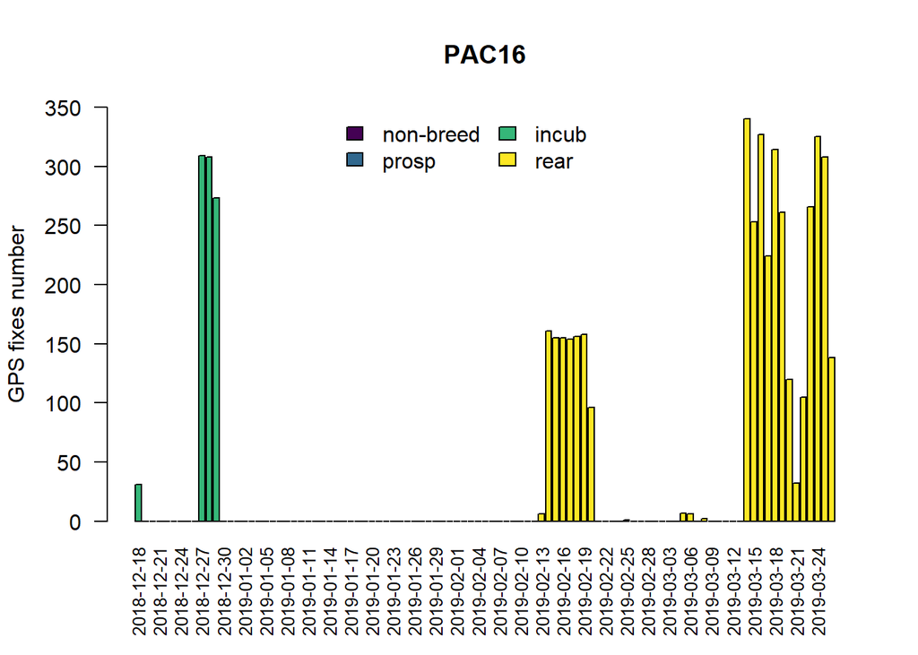